# Life Expectancy by Country

Jorge Paramo, Aldo Carranza, Kevin Nievera

Spring 2015

This is our R Markdown document for our data on life expectancy. Follow this document to reproduce our work in R. To fork our work or find our source files find us on GitHub https://github.com/agcarranza/DV_RProject2.

Our data consisted of 4656 observations on life expectancy in different countries based on sex, income group, region, age, and year.

Here is a summary of our data.

### A Subset Of Our Data

```r
source("../01 Data/OracleData_dataframe.R", echo=TRUE)
```

> require(ggplot2)

> require(gplots)

> require(plyr)

> require(grid)

> require(RCurl)

> require(reshape2)

> require(rstudio)

> require(tableplot)

> require(tidyr)

> require(dplyr)

> lifeData <- data.frame(eval(parse(text = substring(getURL(URLencode(“http://129.152.144.84:5001/rest/native/?query="select * from LIFE_EXPECTANCY" …” … [TRUNCATED]

> knitr::kable(head(lifeData), caption = “Life Expectancy”)

Life Expectancy

| INDICATOR | YEAR | WHO_REGION | WORLD_BANK_INCOME_GROUP | COUNTRY | SEX | LIFE_EXPECTANCY |
| --- | --- | --- | --- | --- | --- | --- |
| Life expectancy at age 60 (years) | 1990 | Europe | High-income | Czech Republic | Female | 19 |
| Life expectancy at birth (years) | 2012 | Europe | High-income | Germany | Male | 78 |
| Life expectancy at age 60 (years) | 2012 | Europe | High-income | Germany | Male | 22 |
| Life expectancy at age 60 (years) | 1990 | Europe | High-income | Germany | Female | 22 |
| Life expectancy at age 60 (years) | 2012 | Europe | High-income | Germany | Both sexes | 24 |
| Life expectancy at birth (years) | 1990 | Europe | High-income | Denmark | Male | 72 |

## Interesting Plots

### World Bank income group and Life Expectancy

Since wealthier people can spend more on healthcare and a better diet, we assumed that people with more income would live longer, so we wanted to test our assumptions. We tested this assumption by discovering which citizens of what country, based on the World Bank Income Groups, lived the longest.

For the R code, we used the filter and summarise functions in the dplyr package to find the average life expectancy at birth of both sexes.

```r
source("../02 Data Wrangling/income_life.R", echo=TRUE)
```

```
##
## > incomeGroup <- lifeData %>% filter(INDICATOR == "Life expectancy at birth (years)",
## +     SEX == "Both sexes") %>% group_by(WORLD_BANK_INCOME_GROUP .... [TRUNCATED]
```

For the vizualiation, we made a bar graph that represents the data. The average life expectancy is on the Y-axis while the income group is on the x-axis.

```r
source("../03 Visualizations/income_life_ggplot.R", echo=TRUE)
```

> ggplot(incomeGroup, aes(x = WORLD_BANK_INCOME_GROUP, + y = avg_life_expectancy, color = WORLD_BANK_INCOME_GROUP, + fill = WORLD_BANK_INCOM …. [TRUNCATED]

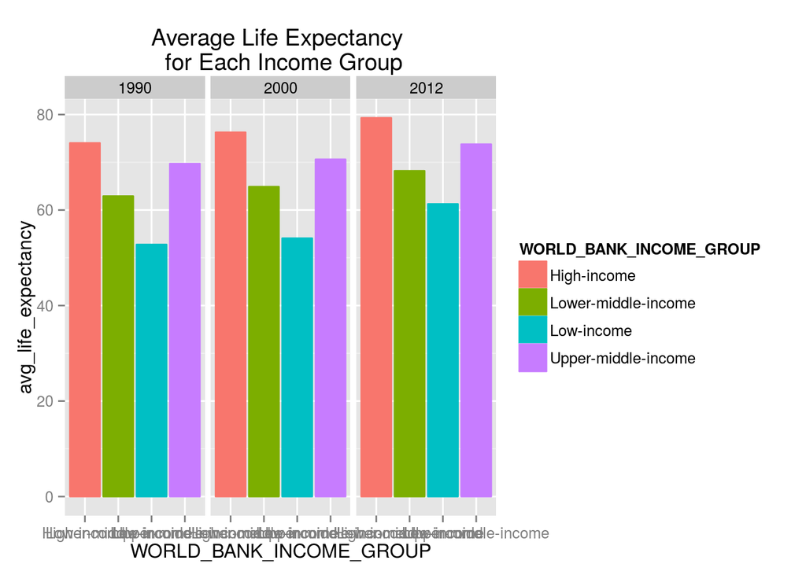

### Top Countries with Highest Life Expectancies

We were curious to see which citizens of what countries had the highest life expectancy at birth. We chose the top countries with the highest life expectancy and checked how these values change for each year the measurements were projected.

We extracted the data that indicated the life expectancy at birth and filtered the data for both sexes to get an average and for each year.

```r
source("../02 Data Wrangling/max_life.R", echo=TRUE)
```

```
##
## > rows <- 7
##
## > max_life1990 <- lifeData %>% filter(INDICATOR == "Life expectancy at birth (years)",
## +     YEAR == 1990, SEX == "Both sexes") %>% arrange(desc(LIFE .... [TRUNCATED]
##
## > max_life2000 <- lifeData %>% filter(INDICATOR == "Life expectancy at birth (years)",
## +     YEAR == 2000, SEX == "Both sexes") %>% arrange(desc(LIFE .... [TRUNCATED]
##
## > max_life2012 <- lifeData %>% filter(INDICATOR == "Life expectancy at birth (years)",
## +     YEAR == 2012, SEX == "Both sexes") %>% arrange(desc(LIFE .... [TRUNCATED]
##
## > max_life <- bind_rows(max_life1990, max_life2000,
## +     max_life2012)
```

The graph shows the life expectancies of the countries with the highest life expectancies per year. Notice that some countries do no have data for certain years. This shows that the ranking of those countries changed so that they are not included in the top 7 countries with highest life expectancy. We used the facet_wrap() function to seperate the plots for each of the three years.

```r
source("../03 Visualizations/max_life_plot.R", echo=TRUE)
```

> require(ggplot2)

> ggplot(max_life, aes(x = COUNTRY, y = LIFE_EXPECTANCY, + color = WHO_REGION)) + geom_bar(stat = “identity”) + coord_cartesian(ylim = c(70, + …. [TRUNCATED]

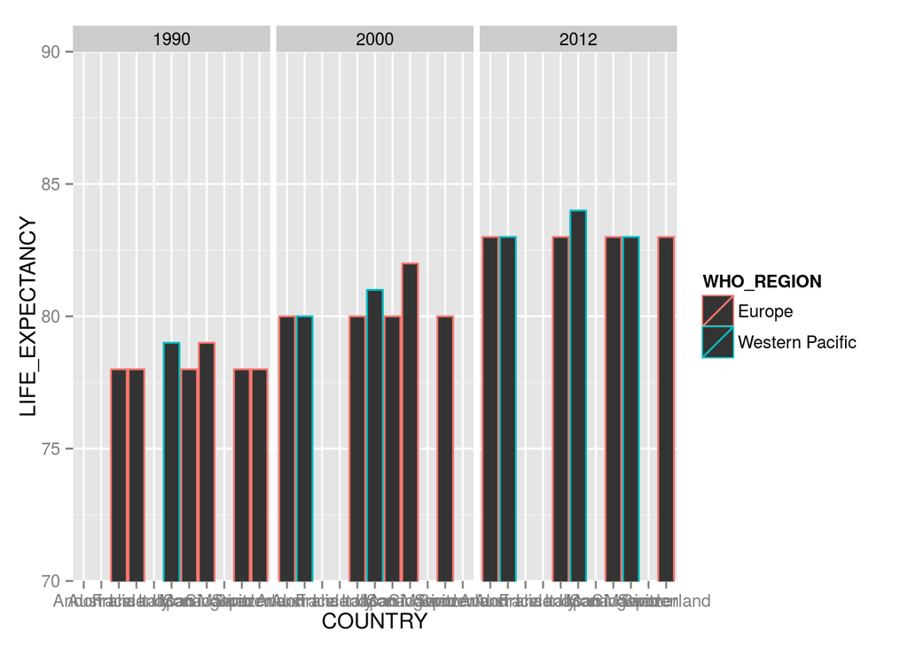

### Life Expectancies per Country

The graph below shows life expectancy on the y-axis and country on the x-axis. The data is grouped by country and year. The color varies based on the year value.

```r
source("../02 Data Wrangling/country_year_life.R", echo=TRUE)
```

```
##
## > life <- lifeData %>% filter(INDICATOR == "Life expectancy at birth (years)") %>%
## +     group_by(COUNTRY, YEAR) %>% select(LIFE_EXPECTANCY) %>% arra .... [TRUNCATED]
```

```r
source("../03 Visualizations/country_life_plot.R", echo=TRUE)
```

> ggplot(life, aes(x = COUNTRY, y = LIFE_EXPECTANCY)) + + geom_point(aes(color = YEAR))

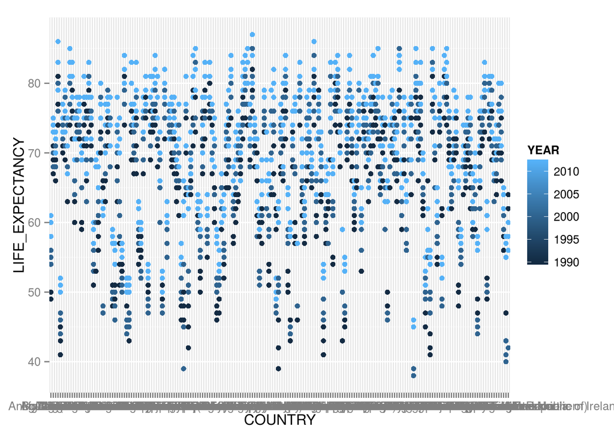